# R Notebook

# Introduction:

The topic for my portfolio project is education. I would like to do some analysis on the changes in education over time with my project. I decided to choose this area to study because education is a very important aspect of every person’s life. It is an area that changes quite frequently and I would like to study some of those changes and how they affect students and teachers. One area that I am interesting in studying in relation to education is how political policies have effected education and student achievement.

# Data:

The first thing I will do is import the first data set that I will be using in my study. To do that I need to install/load some R libraries and then I will read the data into a table.

```r
#install.packages("tidyverse")
suppressMessages(library("tidyverse"))
suppressMessages(library("dplyr"))
suppressMessages(library("tidyr"))

suppressMessages(education_attainment <- read_csv("https://raw.githubusercontent.com/introdsci/DataScience-OliviaAbbott/master/Education.csv"))
```

The data I found gives information on the educational attainment by state and county in the United States. I found this data on the USDA (United States Department of Agriculture) Economic Research Service website. Although it seems odd to find education data on the Department of Agriculture, the website had quite a variety of data available. Since it is a .gov website the data should be reliable for us to use.

I have used colnames to print out all of the column names in the data. And I am using typeof() and mode() to see the type of each of the different columns. I use the sapply() function to applies the function (the second argument) to the entire table (the first argument). I am not going to show the results of sapply functions because the results are so long.

```r
colnames(education_attainment)
```

```
##  [1] "FIPS Code"
##  [2] "State"
##  [3] "Area name"
##  [4] "2003 Rural-urban Continuum Code"
##  [5] "2003 Urban Influence Code"
##  [6] "2013 Rural-urban Continuum Code"
##  [7] "2013 Urban Influence Code"
##  [8] "Less than a high school diploma, 1970"
##  [9] "High school diploma only, 1970"
## [10] "Some college (1-3 years), 1970"
## [11] "Four years of college or higher, 1970"
## [12] "Percent of adults with less than a high school diploma, 1970"
## [13] "Percent of adults with a high school diploma only, 1970"
## [14] "Percent of adults completing some college (1-3 years), 1970"
## [15] "Percent of adults completing four years of college or higher, 1970"
```

[output cut: 33 more lines]

```r
#sapply(education_attainment, typeof)
#sapply(education_attainment, mode)
```

A brief description of the columns in the data:

- FIPS Code: The 5 digit Federal Information Processing Standards code that uniquely identifies counties in the United States.
- State: The name of the state where that county is located
- Area Name: The name of the area where the county is located
- 2003 Rural-urban Continuum Code: 2003 classification scheme that distinguishes metropolitan counties by the population size of their metro area, and nonmetropolitan counties by degree of urbanization and adjacency to a metro area
- 2003 Urban Influence Code: 2003 classification scheme that distinguishes metropolitan counties by population size of their metro area, and nonmetropolitan counties by size of the largest city or town and proximity to metro and micropolitan areas
- 2013 Rural-urban Continuum Code: 2013 classification scheme that distinguishes metropolitan counties by the population size of their metro area, and nonmetropolitan counties by degree of urbanization and adjacency to a metro area
- 2013 Urban Influence Code: 2013 classification scheme that distinguishes metropolitan counties by population size of their metro area, and nonmetropolitan counties by size of the largest city or town and proximity to metro and micropolitan areas
- Less than a high school diploma, 1970: Number of people with less than a high school diploma in 1970
- High school diploma only, 1970: Number of people with a high school diploma in 1970
- Some college (1-3 years), 1970: Number of people with some college completed in 1970
- Four years of college or higher, 1970: Number of people with four years or more of college completed in 1970
- Percent of adults with less than a high school diploma, 1970: Percent of people with less than a high school diploma in 1970
- Percent of adults with a high school diploma only, 1970: Percent of people with a high school diploma in 1970
- Percent of adults completing some college (1-3 years), 1970: Percent of people with some college completed in 1970
- Percent of adults completing four years of college or higher, 1970: Percent of people with four years or more of college completed in 1970

*** The above 8 columns repeat for the years 1980, 1990, 2000, 2013-2017 ***

FIPS Code, State, and Area name are being stored in our table as characters. The rest of the columns are being stored as numbers (specifically doubles).

# Cleaning the data:

The next step is to clean the data so that it can be more easily used. The column names the the educational_attainment table is long and incosistant. So first I will clean up the column names so that they are more readable and are consistant.

```r
colnames(education_attainment)[colnames(education_attainment) == "FIPS Code"] <- "FIPS_Code"
colnames(education_attainment)[colnames(education_attainment) == "Area name"] <- "Area_Name"
colnames(education_attainment)[colnames(education_attainment) == "2003 Rural-urban Continuum Code"] <- "2003_Rural_Urban_Continuum_Code"
colnames(education_attainment)[colnames(education_attainment) == "2003 Urban Influence Code"] <- "2003_Urban_Influence_Code"
colnames(education_attainment)[colnames(education_attainment) == "2013 Rural-urban Continuum Code"] <- "2013_Rural_Urban_Continuum_Code"
colnames(education_attainment)[colnames(education_attainment) == "2013 Urban Influence Code"] <- "2013_Urban_Influence_Code"

colnames(education_attainment)[colnames(education_attainment) == "Less than a high school diploma, 1970"] <- "1970_Less_Than_High_School_Diploma"
colnames(education_attainment)[colnames(education_attainment) == "High school diploma only, 1970"] <- "1970_High_School_Diploma_Only"
colnames(education_attainment)[colnames(education_attainment) == "Some college (1-3 years), 1970"] <- "1970_Some_College"
colnames(education_attainment)[colnames(education_attainment) == "Four years of college or higher, 1970"] <- "1970_Bachelor_Degree_Or_Higher"
colnames(education_attainment)[colnames(education_attainment) == "Percent of adults with less than a high school diploma, 1970"] <- "1970_Percent_Less_Than_High_School_Diploma"
colnames(education_attainment)[colnames(education_attainment) == "Percent of adults with a high school diploma only, 1970"] <- "1970_Percent_High_School_Diploma_Only"
colnames(education_attainment)[colnames(education_attainment) == "Percent of adults completing some college (1-3 years), 1970"] <- "1970_Percent_Some_College"
colnames(education_attainment)[colnames(education_attainment) == "Percent of adults completing four years of college or higher, 1970"] <- "1970_Percent_Bachelor_Degree_Or_Higher"

colnames(education_attainment)[colnames(education_attainment) == "Less than a high school diploma, 1980"] <- "1980_Less_Than_High_School_Diploma"
colnames(education_attainment)[colnames(education_attainment) == "High school diploma only, 1980"] <- "1980_High_School_Diploma_Only"
colnames(education_attainment)[colnames(education_attainment) == "Some college (1-3 years), 1980"] <- "1980_Some_College"
colnames(education_attainment)[colnames(education_attainment) == "Four years of college or higher, 1980"] <- "1980_Bachelor_Degree_Or_Higher"
colnames(education_attainment)[colnames(education_attainment) == "Percent of adults with less than a high school diploma, 1980"] <- "1980_Percent_Less_Than_High_School_Diploma"
colnames(education_attainment)[colnames(education_attainment) == "Percent of adults with a high school diploma only, 1980"] <- "1980_Percent_High_School_Diploma_Only"
colnames(education_attainment)[colnames(education_attainment) == "Percent of adults completing some college (1-3 years), 1980"] <- "1980_Percent_Some_College"
colnames(education_attainment)[colnames(education_attainment) == "Percent of adults completing four years of college or higher, 1980"] <- "1980_Percent_Bachelor_Degree_Or_Higher"

colnames(education_attainment)[colnames(education_attainment) == "Less than a high school diploma, 1990"] <- "1990_Less_Than_High_School_Diploma"
colnames(education_attainment)[colnames(education_attainment) == "High school diploma only, 1990"] <- "1990_High_School_Diploma_Only"
colnames(education_attainment)[colnames(education_attainment) == "Some college or associate's degree, 1990"] <- "1990_Some_College"
colnames(education_attainment)[colnames(education_attainment) == "Bachelor's degree or higher, 1990"] <- "1990_Bachelor_Degree_Or_Higher"
colnames(education_attainment)[colnames(education_attainment) == "Percent of adults with less than a high school diploma, 1990"] <- "1990_Percent_Less_Than_High_School_Diploma"
colnames(education_attainment)[colnames(education_attainment) == "Percent of adults with a high school diploma only, 1990"] <- "1990_Percent_High_School_Diploma_Only"
colnames(education_attainment)[colnames(education_attainment) == "Percent of adults completing some college or associate's degree, 1990"] <- "1990_Percent_Some_College"
colnames(education_attainment)[colnames(education_attainment) == "Percent of adults with a bachelor's degree or higher, 1990"] <- "1990_Percent_Bachelor_Degree_Or_Higher"

colnames(education_attainment)[colnames(education_attainment) == "Less than a high school diploma, 2000"] <- "2000_Less_Than_High_School_Diploma"
colnames(education_attainment)[colnames(education_attainment) == "High school diploma only, 2000"] <- "2000_High_School_Diploma_Only"
colnames(education_attainment)[colnames(education_attainment) == "Some college or associate's degree, 2000"] <- "2000_Some_College"
colnames(education_attainment)[colnames(education_attainment) == "Bachelor's degree or higher, 2000"] <- "2000_Bachelor_Degree_Or_Higher"
colnames(education_attainment)[colnames(education_attainment) == "Percent of adults with less than a high school diploma, 2000"] <- "2000_Percent_Less_Than_High_School_Diploma"
colnames(education_attainment)[colnames(education_attainment) == "Percent of adults with a high school diploma only, 2000"] <- "2000_Percent_High_School_Diploma_Only"
colnames(education_attainment)[colnames(education_attainment) == "Percent of adults completing some college or associate's degree, 2000"] <- "2000_Percent_Some_College"
colnames(education_attainment)[colnames(education_attainment) == "Percent of adults with a bachelor's degree or higher, 2000"] <- "2000_Percent_Bachelor_Degree_Or_Higher"

colnames(education_attainment)[colnames(education_attainment) == "Less than a high school diploma, 2013-17"] <- "2013-17_Less_Than_High_School_Diploma"
colnames(education_attainment)[colnames(education_attainment) == "High school diploma only, 2013-17"] <- "2013-17_High_School_Diploma_Only"
colnames(education_attainment)[colnames(education_attainment) == "Some college or associate's degree, 2013-17"] <- "2013-17_Some_College"
colnames(education_attainment)[colnames(education_attainment) == "Bachelor's degree or higher, 2013-17"] <- "2013-17_Bachelor_Degree_Or_Higher"
colnames(education_attainment)[colnames(education_attainment) == "Percent of adults with less than a high school diploma, 2013-17"] <- "2013-17_Percent_Less_Than_High_School_Diploma"
colnames(education_attainment)[colnames(education_attainment) == "Percent of adults with a high school diploma only, 2013-17"] <- "2013-17_Percent_High_School_Diploma_Only"
colnames(education_attainment)[colnames(education_attainment) == "Percent of adults completing some college or associate's degree, 2013-17"] <- "2013-17_Percent_Some_College"
colnames(education_attainment)[colnames(education_attainment) == "Percent of adults with a bachelor's degree or higher, 2013-17"] <- "2013-17_Percent_Bachelor_Degree_Or_Higher"
```

The next step to clean the data is to remove the last column in the table since it is not holding any data. When importing the data into R an extra column was read in even though it has no data so we can just get rid of that extra column.

```r
education_attainment$X48 <- NULL
```

Next I am going to split the data in education_attainmnet into two different tables. I want to have the location data in a different table from the education attainment data. I am going to create a new table called location using the tibble() function and I will put all of the location data into that table. And I will create a table called education using the same function to hold only the education data.

```r
location <- tibble("FIPS_Code" = education_attainment$FIPS_Code, "State" = education_attainment$State, "Area_Name" = education_attainment$Area_Name, "2003_Rural_Urban_Continuum_Code" = education_attainment$`2003_Rural_Urban_Continuum_Code`,  "2003_Urban_Influence_Code" = education_attainment$`2003_Urban_Influence_Code`, "2013_Rural_Urban_Continuum_Code" = education_attainment$`2013_Rural_Urban_Continuum_Code`, "2013_Urban_Influence_Code" = education_attainment$`2013_Urban_Influence_Code`)

education <- tibble("FIPS_Code" = education_attainment$FIPS_Code, "State" = education_attainment$State, "1970_Less_Than_High_School_Diploma" = education_attainment$`1970_Less_Than_High_School_Diploma`, "1970_High_School_Diploma_Only" = education_attainment$`1970_High_School_Diploma_Only`, "1970_Some_College" = education_attainment$`1970_Some_College`, "1970_Bachelor_Degree_Or_Higher" = education_attainment$`1970_Bachelor_Degree_Or_Higher`, "1970_Percent_Less_Than_High_School_Diploma" = education_attainment$`1970_Percent_Less_Than_High_School_Diploma`, "1970_Percent_High_School_Diploma_Only" = education_attainment$`1970_Percent_High_School_Diploma_Only`, "1970_Percent_Some_College" = education_attainment$`1970_Percent_Some_College`, "1970_Percent_Bachelor_Degree_Or_Higher" = education_attainment$`1980_Percent_Bachelor_Degree_Or_Higher`, "1980_Less_Than_High_School_Diploma" = education_attainment$`1980_Less_Than_High_School_Diploma`, "1980_High_School_Diploma_Only" = education_attainment$`1980_High_School_Diploma_Only`, "1980_Some_College" = education_attainment$`1980_Some_College`, "1980_Bachelor_Degree_Or_Higher" = education_attainment$`1980_Bachelor_Degree_Or_Higher`, "1980_Percent_Less_Than_High_School_Diploma" = education_attainment$`1980_Percent_Less_Than_High_School_Diploma`, "1980_Percent_High_School_Diploma_Only" = education_attainment$`1980_Percent_High_School_Diploma_Only`, "1980_Percent_Some_College" = education_attainment$`1980_Percent_Some_College`, "1980_Percent_Bachelor_Degree_Or_Higher" = education_attainment$`1980_Percent_Bachelor_Degree_Or_Higher`, "1990_Less_Than_High_School_Diploma" = education_attainment$`1990_Less_Than_High_School_Diploma`, "1990_High_School_Diploma_Only" = education_attainment$`1990_High_School_Diploma_Only`, "1990_Some_College" = education_attainment$`1990_Some_College`, "1990_Bachelor_Degree_Or_Higher" = education_attainment$`1990_Bachelor_Degree_Or_Higher`, "1990_Percent_Less_Than_High_School_Diploma" = education_attainment$`1990_Percent_Less_Than_High_School_Diploma`, "1990_Percent_High_School_Diploma_Only" = education_attainment$`1990_Percent_High_School_Diploma_Only`, "1990_Percent_Some_College" = education_attainment$`1990_Percent_Some_College`, "1990_Percent_Bachelor_Degree_Or_Higher" = education_attainment$`1990_Percent_Bachelor_Degree_Or_Higher`, "2000_Less_Than_High_School_Diploma" = education_attainment$`2000_Less_Than_High_School_Diploma`, "2000_High_School_Diploma_Only" = education_attainment$`2000_High_School_Diploma_Only`, "2000_Some_College" = education_attainment$`2000_Some_College`, "2000_Bachelor_Degree_Or_Higher" = education_attainment$`2000_Bachelor_Degree_Or_Higher`, "2000_Percent_Less_Than_High_School_Diploma" = education_attainment$`2000_Percent_Less_Than_High_School_Diploma`, "2000_Percent_High_School_Diploma_Only" = education_attainment$`2000_Percent_High_School_Diploma_Only`, "2000_Percent_Some_College" = education_attainment$`2000_Percent_Some_College`, "2000_Percent_Bachelor_Degree_Or_Higher" = education_attainment$`2000_Percent_Bachelor_Degree_Or_Higher`, "2013-17_Less_Than_High_School_Diploma" = education_attainment$`2013-17_Less_Than_High_School_Diploma`, "2013-17_High_School_Diploma_Only" = education_attainment$`2013-17_High_School_Diploma_Only`, "2013-17_Some_College" = education_attainment$`2013-17_Some_College`, "2013-17_Bachelor_Degree_Or_Higher" = education_attainment$`2013-17_Bachelor_Degree_Or_Higher`, "2013-17_Percent_Less_Than_High_School_Diploma" = education_attainment$`2013-17_Percent_Less_Than_High_School_Diploma`, "2013-17_Percent_High_School_Diploma_Only" = education_attainment$`2013-17_Percent_High_School_Diploma_Only`, "2013-17_Percent_Some_College" = education_attainment$`2013-17_Percent_Some_College`, "2013-17_Percent_Bachelor_Degree_Or_Higher" = education_attainment$`2013-17_Percent_Bachelor_Degree_Or_Higher`)
```

The next step to cleaning the data is to change some of the columns in the education table that are being represented as doubles to integers. We want the columns holding the percent values to be doubles, however the columns not holding percent values can be integers.

```r
education$`1970_Less_Than_High_School_Diploma` <- type.convert(education$`1970_Less_Than_High_School_Diploma`)
education$`1970_High_School_Diploma_Only` <- type.convert(education$`1970_High_School_Diploma_Only`)
education$`1970_Some_College` <- type.convert(education$`1970_Some_College`)
education$`1970_Bachelor_Degree_Or_Higher` <- type.convert(education$`1970_Bachelor_Degree_Or_Higher`)
education$`1980_Less_Than_High_School_Diploma` <- type.convert(education$`1980_Less_Than_High_School_Diploma`)
education$`1980_High_School_Diploma_Only` <- type.convert(education$`1980_High_School_Diploma_Only`)
education$`1980_Some_College` <- type.convert(education$`1980_Some_College`)
education$`1980_Bachelor_Degree_Or_Higher` <- type.convert(education$`1980_Bachelor_Degree_Or_Higher`)
education$`1990_Less_Than_High_School_Diploma` <- type.convert(education$`1990_Less_Than_High_School_Diploma`)
education$`1990_High_School_Diploma_Only` <- type.convert(education$`1990_High_School_Diploma_Only`)
education$`1990_Some_College` <- type.convert(education$`1990_Some_College`)
education$`1990_Bachelor_Degree_Or_Higher` <- type.convert(education$`1990_Bachelor_Degree_Or_Higher`)
education$`2000_Less_Than_High_School_Diploma` <- type.convert(education$`2000_Less_Than_High_School_Diploma`)
education$`2000_High_School_Diploma_Only` <- type.convert(education$`2000_High_School_Diploma_Only`)
education$`2000_Some_College` <- type.convert(education$`2000_Some_College`)
education$`2000_Bachelor_Degree_Or_Higher` <- type.convert(education$`2000_Bachelor_Degree_Or_Higher`)
education$`2013-17_Less_Than_High_School_Diploma` <- type.convert(education$`2013-17_Less_Than_High_School_Diploma`)
education$`2013-17_High_School_Diploma_Only` <- type.convert(education$`2013-17_High_School_Diploma_Only`)
education$`2013-17_Some_College` <- type.convert(education$`2013-17_Some_College`)
education$`2013-17_Bachelor_Degree_Or_Higher` <- type.convert(education$`2013-17_Bachelor_Degree_Or_Higher`)
```

I am also going to update any columns that should be represented as categories by making them categorical using the as.factor() funtion.

```r
location$State <- as.factor(location$State)
levels(location$State)
```

```
##  [1] "AK" "AL" "AR" "AZ" "CA" "CO" "CT" "DC" "DE" "FL" "GA" "HI" "IA" "ID"
## [15] "IL" "IN" "KS" "KY" "LA" "MA" "MD" "ME" "MI" "MN" "MO" "MS" "MT" "NC"
## [29] "ND" "NE" "NH" "NJ" "NM" "NV" "NY" "OH" "OK" "OR" "PA" "PR" "RI" "SC"
## [43] "SD" "TN" "TX" "US" "UT" "VA" "VT" "WA" "WI" "WV" "WY"
```

```r
location$`2003_Rural_Urban_Continuum_Code` <- as.factor(location$`2003_Rural_Urban_Continuum_Code`)
levels(location$`2003_Rural_Urban_Continuum_Code`)
```

```
## [1] "1" "2" "3" "4" "5" "6" "7" "8" "9"
```

```r
location$`2003_Urban_Influence_Code` <- as.factor(location$`2003_Urban_Influence_Code`)
levels(location$`2003_Urban_Influence_Code`)
```

```
##  [1] "1"  "2"  "3"  "4"  "5"  "6"  "7"  "8"  "9"  "10" "11" "12"
```

```r
location$`2013_Rural_Urban_Continuum_Code` <- as.factor(location$`2013_Rural_Urban_Continuum_Code`)
levels(location$`2013_Rural_Urban_Continuum_Code`)
```

```
## [1] "1" "2" "3" "4" "5" "6" "7" "8" "9"
```

```r
location$`2013_Urban_Influence_Code` <- as.factor(location$`2013_Urban_Influence_Code`)
levels(location$`2013_Urban_Influence_Code`)
```

```
##  [1] "1"  "2"  "3"  "4"  "5"  "6"  "7"  "8"  "9"  "10" "11" "12"
```

```r
education$State <- as.factor(education$State)
levels(education$State)
```

```
##  [1] "AK" "AL" "AR" "AZ" "CA" "CO" "CT" "DC" "DE" "FL" "GA" "HI" "IA" "ID"
## [15] "IL" "IN" "KS" "KY" "LA" "MA" "MD" "ME" "MI" "MN" "MO" "MS" "MT" "NC"
## [29] "ND" "NE" "NH" "NJ" "NM" "NV" "NY" "OH" "OK" "OR" "PA" "PR" "RI" "SC"
## [43] "SD" "TN" "TX" "US" "UT" "VA" "VT" "WA" "WI" "WV" "WY"
```

# Data Summarizations:

To first make some data summarizations I am going to use the summary() function to give a brief overview of each column.

Summaries for the year 1970:

```r
#summary for 1970
summary(education$`1970_Less_Than_High_School_Diploma`)
```

```
##     Min.  1st Qu.   Median     Mean  3rd Qu.     Max.     NA's
##        6     3020     6032    49316    12466 52373312      476
```

```r
summary(education$`1970_High_School_Diploma_Only`)
```

```
##     Min.  1st Qu.   Median     Mean  3rd Qu.     Max.     NA's
##        8     1264     2794    32164     7170 34158051      476
```

```r
summary(education$`1970_Some_College`)
```

```
##     Min.  1st Qu.   Median     Mean  3rd Qu.     Max.     NA's
##        0      376      810    10971     2155 11650730      476
```

```r
summary(education$`1970_Bachelor_Degree_Or_Higher`)
```

```
##     Min.  1st Qu.   Median     Mean  3rd Qu.     Max.     NA's
##        0      278      610    11033     1819 11717266      476
```

Summaries for the year 1980:

```r
#summary for 1980
summary(education$`1980_Less_Than_High_School_Diploma`)
```

```
##     Min.  1st Qu.   Median     Mean  3rd Qu.     Max.     NA's
##       31     2694     5639    41480    11816 44535197      395
```

```r
summary(education$`1980_High_School_Diploma_Only`)
```

```
##     Min.  1st Qu.   Median     Mean  3rd Qu.     Max.     NA's
##       21     1982     4257    42396    10626 45947035      395
```

```r
summary(education$`1980_Some_College`)
```

```
##     Min.  1st Qu.   Median     Mean  3rd Qu.     Max.     NA's
##        6      660     1433    19183     3997 20794975      395
```

```r
summary(education$`1980_Bachelor_Degree_Or_Higher`)
```

```
##     Min.  1st Qu.   Median     Mean  3rd Qu.     Max.     NA's
##        3      538     1187    19887     3490 21558480      395
```

Summaries for the year 1990:

```r
summary(education$`1990_Less_Than_High_School_Diploma`)
```

```
##     Min.  1st Qu.   Median     Mean  3rd Qu.     Max.     NA's
##        0     2207     4827    36685    10400 39343718      391
```

```r
summary(education$`1990_High_School_Diploma_Only`)
```

```
##     Min.  1st Qu.   Median     Mean  3rd Qu.     Max.     NA's
##        0     2306     4932    43947    11934 47642763      391
```

```r
summary(education$`1990_Some_College`)
```

```
##     Min.  1st Qu.   Median     Mean  3rd Qu.     Max.     NA's
##       16     1246     2768    36465     8150 39571702      391
```

```r
summary(education$`1990_Bachelor_Degree_Or_Higher`)
```

```
##     Min.  1st Qu.   Median     Mean  3rd Qu.     Max.     NA's
##        0      674     1567    29804     5043 32310253      391
```

Summaries for the year 2000:

```r
#summary for 2000
summary(education$`2000_Less_Than_High_School_Diploma`)
```

```
##     Min.  1st Qu.   Median     Mean  3rd Qu.     Max.     NA's
##        7     1769     4105    33327     9068 35715625      390
```

```r
summary(education$`2000_High_School_Diploma_Only`)
```

```
##     Min.  1st Qu.   Median     Mean  3rd Qu.     Max.     NA's
##       19     2694     5808    48113    14104 52168981      390
```

```r
summary(education$`2000_Some_College`)
```

```
##     Min.  1st Qu.   Median     Mean  3rd Qu.     Max.     NA's
##       14     1797     4018    45941    11256 49864428      390
```

```r
summary(education$`2000_Bachelor_Degree_Or_Higher`)
```

```
##     Min.  1st Qu.   Median     Mean  3rd Qu.     Max.     NA's
##        3      916     2250    40979     7264 44462605      390
```

Summary for the years 2013-17:

```r
#summary for 2013-17
summary(education$`2013-17_Less_Than_High_School_Diploma`)
```

```
##     Min.  1st Qu.   Median     Mean  3rd Qu.     Max.     NA's
##        4     1074     2729    25519     6365 27437114      389
```

```r
summary(education$`2013-17_High_School_Diploma_Only`)
```

```
##     Min.  1st Qu.   Median     Mean  3rd Qu.     Max.     NA's
##       20     2888     6539    54568    16027 59093612      389
```

```r
summary(education$`2013-17_Some_College`)
```

```
##     Min.  1st Qu.   Median     Mean  3rd Qu.     Max.     NA's
##       27     2323     5384    57935    14796 62853315      389
```

```r
summary(education$`2013-17_Bachelor_Degree_Or_Higher`)
```

```
##     Min.  1st Qu.   Median     Mean  3rd Qu.     Max.     NA's
##        3     1224     3264    61673    10938 66887603      389
```

By just using the summary() function you are able to see the shift in how educated people are over the years. The highest average number of people for 1970 is the “less than a high school diploma” group. By 1980 “less than a high school diploma” and “high school diploma only” have close to the same average number of people. In 1990 the highest average number of people is now just “high school diploma only”. For the year 2000, “high school diploma only”, “some college”, and “bachelor degree or higher” all have a very close average number of people. And by the years 2013-17 “bachelor degree or higher” now has the highest average number of students.

```r
library("ggplot2")

mean(education$`1970_Less_Than_High_School_Diploma`, na.rm = TRUE)
```

```
## [1] 49315.74
```

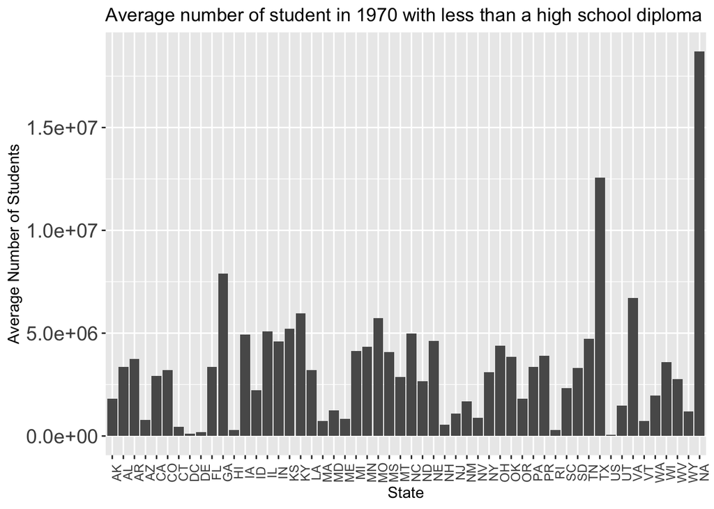

```r
ggplot(education, aes(State, mean(`1970_Less_Than_High_School_Diploma`, na.rm = TRUE))) + geom_col() + labs( x = "State", y = "Average Number of Students",
title ="Average number of student in 1970 with less than a high school diploma") +
  theme(axis.text.x = element_text(size = 9, angle=90), axis.text.y = element_text(size=14))
```

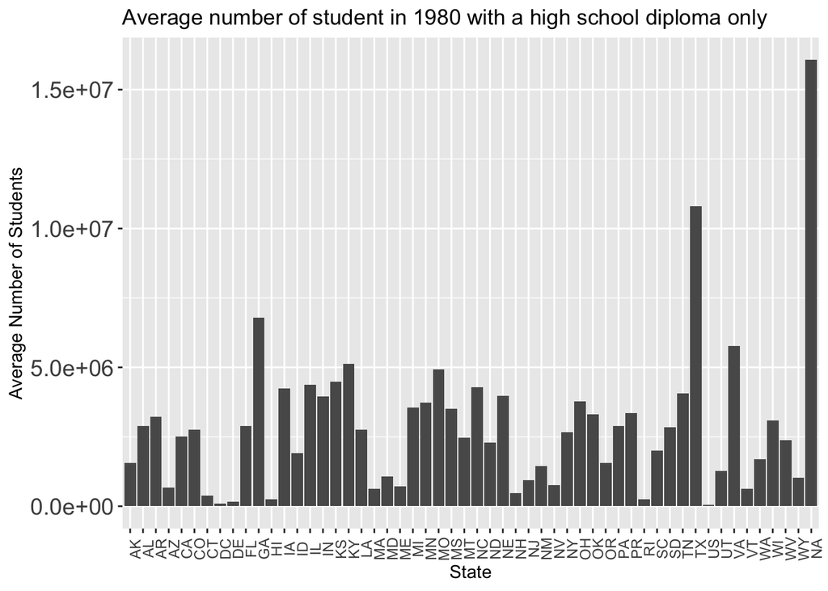

```r
ggplot(education, aes(State, mean(`1980_High_School_Diploma_Only`, na.rm = TRUE))) + geom_col() + labs( x = "State", y = "Average Number of Students",
title ="Average number of student in 1980 with a high school diploma only") +
  theme(axis.text.x = element_text(size = 9, angle=90), axis.text.y = element_text(size=14))
```

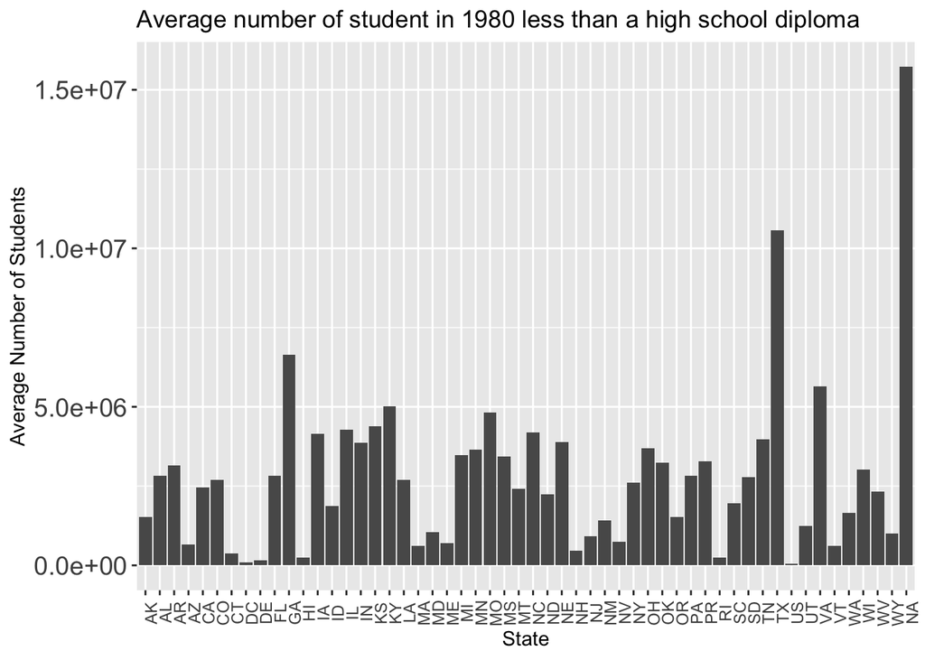

```r
ggplot(education, aes(State, mean(`1980_Less_Than_High_School_Diploma`, na.rm = TRUE))) + geom_col() + labs( x = "State", y = "Average Number of Students",
title ="Average number of student in 1980 less than a high school diploma") +
  theme(axis.text.x = element_text(size = 9, angle=90), axis.text.y = element_text(size=14))
```

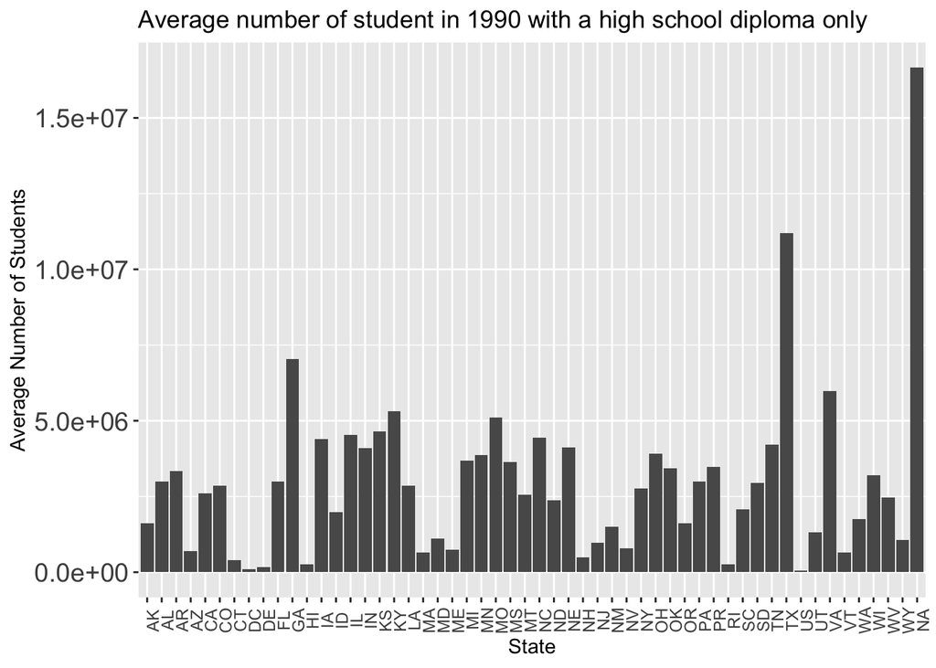

```r
ggplot(education, aes(State, mean(`1990_High_School_Diploma_Only`, na.rm = TRUE))) + geom_col() + labs( x = "State", y = "Average Number of Students",
title ="Average number of student in 1990 with a high school diploma only") +
  theme(axis.text.x = element_text(size = 9, angle=90), axis.text.y = element_text(size=14))
```

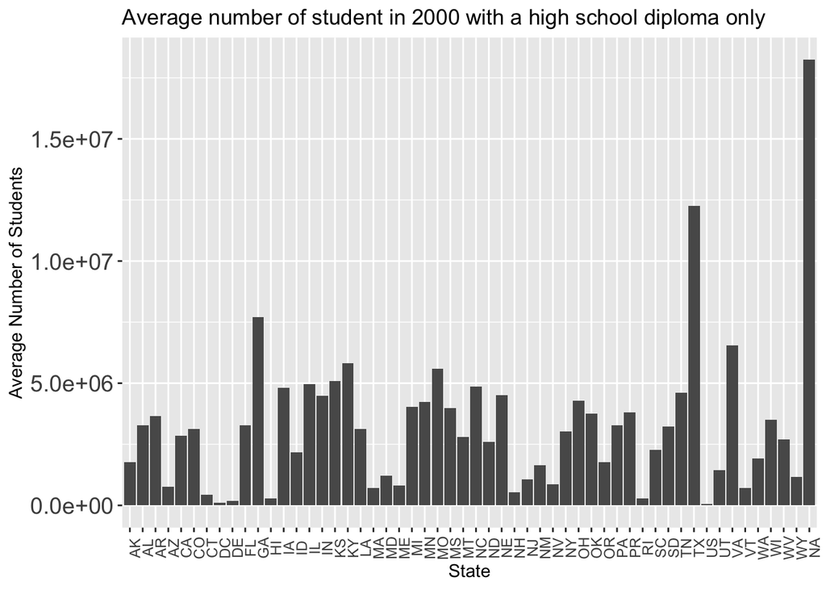

```r
ggplot(education, aes(State, mean(`2000_High_School_Diploma_Only`, na.rm = TRUE))) + geom_col() + labs( x = "State", y = "Average Number of Students",
title ="Average number of student in 2000 with a high school diploma only") +
  theme(axis.text.x = element_text(size = 9, angle=90), axis.text.y = element_text(size=14))
```

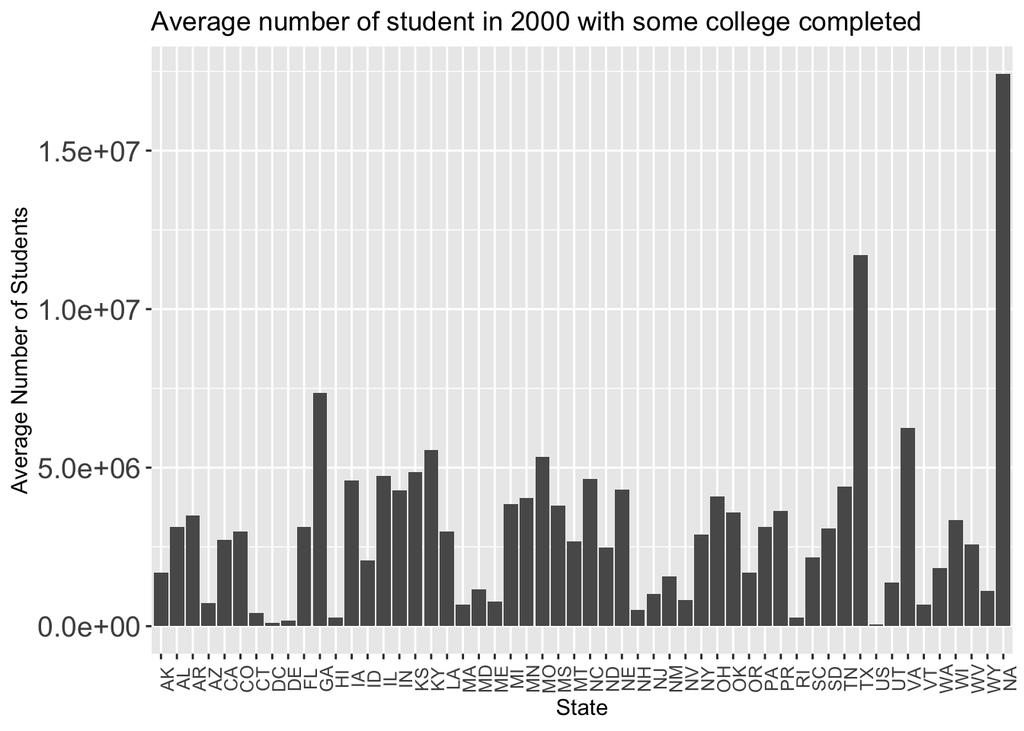

```r
ggplot(education, aes(State, mean(`2000_Some_College`, na.rm = TRUE))) + geom_col() +
  labs( x = "State", y = "Average Number of Students",
  title ="Average number of student in 2000 with some college completed") +
  theme(axis.text.x = element_text(size = 9, angle=90), axis.text.y = element_text(size=14))
```

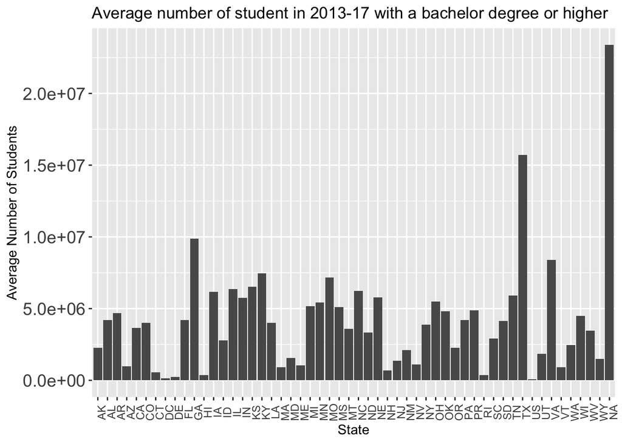

```r
ggplot(education, aes(State, mean(`2013-17_Bachelor_Degree_Or_Higher`, na.rm = TRUE))) + geom_col() +
  labs( x = "State", y = "Average Number of Students",
  title ="Average number of student in 2013-17 with a bachelor degree or higher") +
  theme(axis.text.x = element_text(size = 9, angle=90), axis.text.y = element_text(size=14)) +
  scale_y_continuous()
```

I think that the limitation to these graphs is that the average number of people is dependent on the population in that state. So you should not compare the states to each to each other people each of the states total population is different.

# Research Questions

Do major education political policies have a positive effect on student learning and achievement?

What is the most signifigant factor that has caused there to be an increase in people who have completed a college degree?

What is the most signifigant economical effect caused by the increase in people going to college now compared to 20 years ago?

What action can local government take to improve the education system for the employees?

How has education employment changed over time and are those changes related to the changes in education achievement?